# Explore Movie Dataset

## 探索电影数据集

在这个项目中，你将尝试使用所学的知识，使用 `NumPy`、`Pandas`、`matplotlib`、`seaborn` 库中的函数，来对电影数据集进行探索。

下载数据集： [TMDb电影数据](https://s3.cn-north-1.amazonaws.com.cn/static-documents/nd101/explore+dataset/tmdb-movies.csv)

数据集各列名称的含义：

| 列名称 | id | imdb_id | popularity | budget | revenue | original_title | cast | homepage | director | tagline | keywords | overview | runtime | genres | production_companies | release_date | vote_count | vote_average | release_year | budget_adj | revenue_adj |
| --- | --- | --- | --- | --- | --- | --- | --- | --- | --- | --- | --- | --- | --- | --- | --- | --- | --- | --- | --- | --- | --- |
| 含义 | 编号 | IMDB 编号 | 知名度 | 预算 | 票房 | 名称 | 主演 | 网站 | 导演 | 宣传词 | 关键词 | 简介 | 时常 | 类别 | 发行公司 | 发行日期 | 投票总数 | 投票均值 | 发行年份 | 预算（调整后） | 票房（调整后） |

**请注意，你需要提交该报告导出的 `.html`、`.ipynb` 以及 `.py` 文件。**

## 第一节 数据的导入与处理

在这一部分，你需要编写代码，使用 Pandas 读取数据，并进行预处理。

**任务1.1：** 导入库以及数据

1. 载入需要的库 `NumPy`、`Pandas`、`matplotlib`、`seaborn`。
2. 利用 `Pandas` 库，读取 `tmdb-movies.csv` 中的数据，保存为 `movie_data`。

提示：记得使用 notebook 中的魔法指令 `%matplotlib inline`，否则会导致你接下来无法打印出图像。

```python
# 1.import packages into Python
import numpy as np
import pandas as pd
import matplotlib.pyplot as plt
import seaborn as sb

%matplotlib inline

# 2.read data
movie_data = pd.read_csv('./tmdb-movies.csv')
movie_data.head()
```

|  | id | imdb_id | popularity | budget | revenue | original_title | cast | homepage | director | tagline | ... | overview | runtime | genres | production_companies | release_date | vote_count | vote_average | release_year | budget_adj | revenue_adj |
| --- | --- | --- | --- | --- | --- | --- | --- | --- | --- | --- | --- | --- | --- | --- | --- | --- | --- | --- | --- | --- | --- |
| 0 | 135397 | tt0369610 | 32.985763 | 150000000 | 1513528810 | Jurassic World | Chris Pratt\|Bryce Dallas Howard\|Irrfan Khan\|Vi... | http://www.jurassicworld.com/ | Colin Trevorrow | The park is open. | ... | Twenty-two years after the events of Jurassic ... | 124 | Action\|Adventure\|Science Fiction\|Thriller | Universal Studios\|Amblin Entertainment\|Legenda... | 6/9/15 | 5562 | 6.5 | 2015 | 1.379999e+08 | 1.392446e+09 |
| 1 | 76341 | tt1392190 | 28.419936 | 150000000 | 378436354 | Mad Max: Fury Road | Tom Hardy\|Charlize Theron\|Hugh Keays-Byrne\|Nic... | http://www.madmaxmovie.com/ | George Miller | What a Lovely Day. | ... | An apocalyptic story set in the furthest reach... | 120 | Action\|Adventure\|Science Fiction\|Thriller | Village Roadshow Pictures\|Kennedy Miller Produ... | 5/13/15 | 6185 | 7.1 | 2015 | 1.379999e+08 | 3.481613e+08 |
| 2 | 262500 | tt2908446 | 13.112507 | 110000000 | 295238201 | Insurgent | Shailene Woodley\|Theo James\|Kate Winslet\|Ansel... | http://www.thedivergentseries.movie/#insurgent | Robert Schwentke | One Choice Can Destroy You | ... | Beatrice Prior must confront her inner demons ... | 119 | Adventure\|Science Fiction\|Thriller | Summit Entertainment\|Mandeville Films\|Red Wago... | 3/18/15 | 2480 | 6.3 | 2015 | 1.012000e+08 | 2.716190e+08 |
| 3 | 140607 | tt2488496 | 11.173104 | 200000000 | 2068178225 | Star Wars: The Force Awakens | Harrison Ford\|Mark Hamill\|Carrie Fisher\|Adam D... | http://www.starwars.com/films/star-wars-episod... | J.J. Abrams | Every generation has a story. | ... | Thirty years after defeating the Galactic Empi... | 136 | Action\|Adventure\|Science Fiction\|Fantasy | Lucasfilm\|Truenorth Productions\|Bad Robot | 12/15/15 | 5292 | 7.5 | 2015 | 1.839999e+08 | 1.902723e+09 |
| 4 | 168259 | tt2820852 | 9.335014 | 190000000 | 1506249360 | Furious 7 | Vin Diesel\|Paul Walker\|Jason Statham\|Michelle ... | http://www.furious7.com/ | James Wan | Vengeance Hits Home | ... | Deckard Shaw seeks revenge against Dominic Tor... | 137 | Action\|Crime\|Thriller | Universal Pictures\|Original Film\|Media Rights ... | 4/1/15 | 2947 | 7.3 | 2015 | 1.747999e+08 | 1.385749e+09 |

5 rows × 21 columns

**任务1.2:** 了解数据

你会接触到各种各样的数据表，因此在读取之后，我们有必要通过一些简单的方法，来了解我们数据表是什么样子的。

1. 获取数据表的行列，并打印。
2. 使用 `.head()`、`.tail()`、`.sample()` 方法，观察、了解数据表的情况。
3. 使用 `.dtypes` 属性，来查看各列数据的数据类型。
4. 使用 `isnull()` 配合 `.any()` 等方法，来查看各列是否存在空值。
5. 使用 `.describe()` 方法，看看数据表中数值型的数据是怎么分布的。

```python
# 1
print(movie_data.columns.values.tolist())
print(movie_data.index.values.tolist())
```

[output not shown]

```python
# 2.1
movie_data.head()
```

|  | id | imdb_id | popularity | budget | revenue | original_title | cast | homepage | director | tagline | ... | overview | runtime | genres | production_companies | release_date | vote_count | vote_average | release_year | budget_adj | revenue_adj |
| --- | --- | --- | --- | --- | --- | --- | --- | --- | --- | --- | --- | --- | --- | --- | --- | --- | --- | --- | --- | --- | --- |
| 0 | 135397 | tt0369610 | 32.985763 | 150000000 | 1513528810 | Jurassic World | Chris Pratt\|Bryce Dallas Howard\|Irrfan Khan\|Vi... | http://www.jurassicworld.com/ | Colin Trevorrow | The park is open. | ... | Twenty-two years after the events of Jurassic ... | 124 | Action\|Adventure\|Science Fiction\|Thriller | Universal Studios\|Amblin Entertainment\|Legenda... | 6/9/15 | 5562 | 6.5 | 2015 | 1.379999e+08 | 1.392446e+09 |
| 1 | 76341 | tt1392190 | 28.419936 | 150000000 | 378436354 | Mad Max: Fury Road | Tom Hardy\|Charlize Theron\|Hugh Keays-Byrne\|Nic... | http://www.madmaxmovie.com/ | George Miller | What a Lovely Day. | ... | An apocalyptic story set in the furthest reach... | 120 | Action\|Adventure\|Science Fiction\|Thriller | Village Roadshow Pictures\|Kennedy Miller Produ... | 5/13/15 | 6185 | 7.1 | 2015 | 1.379999e+08 | 3.481613e+08 |
| 2 | 262500 | tt2908446 | 13.112507 | 110000000 | 295238201 | Insurgent | Shailene Woodley\|Theo James\|Kate Winslet\|Ansel... | http://www.thedivergentseries.movie/#insurgent | Robert Schwentke | One Choice Can Destroy You | ... | Beatrice Prior must confront her inner demons ... | 119 | Adventure\|Science Fiction\|Thriller | Summit Entertainment\|Mandeville Films\|Red Wago... | 3/18/15 | 2480 | 6.3 | 2015 | 1.012000e+08 | 2.716190e+08 |
| 3 | 140607 | tt2488496 | 11.173104 | 200000000 | 2068178225 | Star Wars: The Force Awakens | Harrison Ford\|Mark Hamill\|Carrie Fisher\|Adam D... | http://www.starwars.com/films/star-wars-episod... | J.J. Abrams | Every generation has a story. | ... | Thirty years after defeating the Galactic Empi... | 136 | Action\|Adventure\|Science Fiction\|Fantasy | Lucasfilm\|Truenorth Productions\|Bad Robot | 12/15/15 | 5292 | 7.5 | 2015 | 1.839999e+08 | 1.902723e+09 |
| 4 | 168259 | tt2820852 | 9.335014 | 190000000 | 1506249360 | Furious 7 | Vin Diesel\|Paul Walker\|Jason Statham\|Michelle ... | http://www.furious7.com/ | James Wan | Vengeance Hits Home | ... | Deckard Shaw seeks revenge against Dominic Tor... | 137 | Action\|Crime\|Thriller | Universal Pictures\|Original Film\|Media Rights ... | 4/1/15 | 2947 | 7.3 | 2015 | 1.747999e+08 | 1.385749e+09 |

5 rows × 21 columns

```python
# 2.2
movie_data.tail()
```

|  | id | imdb_id | popularity | budget | revenue | original_title | cast | homepage | director | tagline | ... | overview | runtime | genres | production_companies | release_date | vote_count | vote_average | release_year | budget_adj | revenue_adj |
| --- | --- | --- | --- | --- | --- | --- | --- | --- | --- | --- | --- | --- | --- | --- | --- | --- | --- | --- | --- | --- | --- |
| 10861 | 21 | tt0060371 | 0.080598 | 0 | 0 | The Endless Summer | Michael Hynson\|Robert August\|Lord 'Tally Ho' B... | NaN | Bruce Brown | NaN | ... | The Endless Summer, by Bruce Brown, is one of ... | 95 | Documentary | Bruce Brown Films | 6/15/66 | 11 | 7.4 | 1966 | 0.000000 | 0.0 |
| 10862 | 20379 | tt0060472 | 0.065543 | 0 | 0 | Grand Prix | James Garner\|Eva Marie Saint\|Yves Montand\|Tosh... | NaN | John Frankenheimer | Cinerama sweeps YOU into a drama of speed and ... | ... | Grand Prix driver Pete Aron is fired by his te... | 176 | Action\|Adventure\|Drama | Cherokee Productions\|Joel Productions\|Douglas ... | 12/21/66 | 20 | 5.7 | 1966 | 0.000000 | 0.0 |
| 10863 | 39768 | tt0060161 | 0.065141 | 0 | 0 | Beregis Avtomobilya | Innokentiy Smoktunovskiy\|Oleg Efremov\|Georgi Z... | NaN | Eldar Ryazanov | NaN | ... | An insurance agent who moonlights as a carthie... | 94 | Mystery\|Comedy | Mosfilm | 1/1/66 | 11 | 6.5 | 1966 | 0.000000 | 0.0 |
| 10864 | 21449 | tt0061177 | 0.064317 | 0 | 0 | What's Up, Tiger Lily? | Tatsuya Mihashi\|Akiko Wakabayashi\|Mie Hama\|Joh... | NaN | Woody Allen | WOODY ALLEN STRIKES BACK! | ... | In comic Woody Allen's film debut, he took the... | 80 | Action\|Comedy | Benedict Pictures Corp. | 11/2/66 | 22 | 5.4 | 1966 | 0.000000 | 0.0 |
| 10865 | 22293 | tt0060666 | 0.035919 | 19000 | 0 | Manos: The Hands of Fate | Harold P. Warren\|Tom Neyman\|John Reynolds\|Dian... | NaN | Harold P. Warren | It's Shocking! It's Beyond Your Imagination! | ... | A family gets lost on the road and stumbles up... | 74 | Horror | Norm-Iris | 11/15/66 | 15 | 1.5 | 1966 | 127642.279154 | 0.0 |

5 rows × 21 columns

```python
# 2.3
movie_data.sample()
```

|  | id | imdb_id | popularity | budget | revenue | original_title | cast | homepage | director | tagline | ... | overview | runtime | genres | production_companies | release_date | vote_count | vote_average | release_year | budget_adj | revenue_adj |
| --- | --- | --- | --- | --- | --- | --- | --- | --- | --- | --- | --- | --- | --- | --- | --- | --- | --- | --- | --- | --- | --- |
| 6274 | 5289 | tt0402910 | 0.79295 | 12000000 | 10289 | Chaos | Jason Statham\|Ryan Phillippe\|Wesley Snipes\|Hen... | NaN | Tony Giglio | When the system breaks down... someone is abou... | ... | Two cops, a rookie and a grizzled vet, pursue ... | 106 | Drama\|Action\|Crime | Current Entertainment\|Epsilon Motion Pictures\|... | 1/17/05 | 162 | 6.3 | 2005 | 1.339876e+07 | 11488.319687 |

1 rows × 21 columns

```python
# 3
movie_columns_list = movie_data.columns.values.tolist()
type(movie_columns_list)
for i in range(len(movie_columns_list)):
    print(movie_data[[movie_columns_list[i]]].dtypes)
```

```
id    int64
dtype: object
imdb_id    object
dtype: object
popularity    float64
dtype: object
budget    int64
dtype: object
revenue    int64
dtype: object
original_title    object
dtype: object
cast    object
dtype: object
homepage    object
dtype: object
director    object
dtype: object
tagline    object
dtype: object
keywords    object
dtype: object
overview    object
dtype: object
runtime    int64
dtype: object
genres    object
dtype: object
production_companies    object
dtype: object
release_date    object
dtype: object
vote_count    int64
dtype: object
vote_average    float64
dtype: object
release_year    int64
dtype: object
budget_adj    float64
dtype: object
revenue_adj    float64
dtype: object
```

```python
# 4
movie_data.isnull().sum()
```

```
id                         0
imdb_id                   10
popularity                 0
budget                     0
revenue                    0
original_title             0
cast                      76
homepage                7930
director                  44
tagline                 2824
keywords                1493
overview                   4
runtime                    0
genres                    23
production_companies    1030
release_date               0
vote_count                 0
vote_average               0
release_year               0
budget_adj                 0
revenue_adj                0
dtype: int64
```

```python
for i in range(len(movie_columns_list)):
    print(movie_data[[movie_columns_list[i]]].describe())
```

```
                  id
count   10866.000000
mean    66064.177434
std     92130.136561
min         5.000000
25%     10596.250000
50%     20669.000000
75%     75610.000000
max    417859.000000
          imdb_id
count       10856
unique      10855
top     tt0411951
freq            2
         popularity
count  10866.000000
mean       0.646441
std        1.000185
min        0.000065
25%        0.207583
50%        0.383856
75%        0.713817
max       32.985763
             budget
count  1.086600e+04
mean   1.462570e+07
std    3.091321e+07
min    0.000000e+00
25%    0.000000e+00
50%    0.000000e+00
75%    1.500000e+07
max    4.250000e+08
            revenue
count  1.086600e+04
mean   3.982332e+07
std    1.170035e+08
min    0.000000e+00
25%    0.000000e+00
50%    0.000000e+00
75%    2.400000e+07
```

[output cut: 90 more lines]

```
std    3.430616e+07
min    0.000000e+00
25%    0.000000e+00
50%    0.000000e+00
75%    2.085325e+07
max    4.250000e+08
        revenue_adj
count  1.086600e+04
mean   5.136436e+07
std    1.446325e+08
min    0.000000e+00
25%    0.000000e+00
50%    0.000000e+00
75%    3.369710e+07
max    2.827124e+09
```

**任务1.3:** 清理数据

在真实的工作场景中，数据处理往往是最为费时费力的环节。但是幸运的是，我们提供给大家的 tmdb 数据集非常的「干净」，不需要大家做特别多的数据清洗以及处理工作。在这一步中，你的核心的工作主要是对数据表中的空值进行处理。你可以使用 `.fillna()` 来填补空值，当然也可以使用 `.dropna()` 来丢弃数据表中包含空值的某些行或者列。

任务：使用适当的方法来清理空值，并将得到的数据保存。

```python
# clean data
clean_data = movie_data.dropna(axis=0)
clean_data.isnull().sum()
```

```
id                      0
imdb_id                 0
popularity              0
budget                  0
revenue                 0
original_title          0
cast                    0
homepage                0
director                0
tagline                 0
keywords                0
overview                0
runtime                 0
genres                  0
production_companies    0
release_date            0
vote_count              0
vote_average            0
release_year            0
budget_adj              0
revenue_adj             0
dtype: int64
```

## 第二节 根据指定要求读取数据

相比 Excel 等数据分析软件，Pandas 的一大特长在于，能够轻松地基于复杂的逻辑选择合适的数据。因此，如何根据指定的要求，从数据表当获取适当的数据，是使用 Pandas 中非常重要的技能，也是本节重点考察大家的内容。

**任务2.1:** 简单读取

1. 读取数据表中名为 `id`、`popularity`、`budget`、`runtime`、`vote_average` 列的数据。
2. 读取数据表中前1～20行以及48、49行的数据。
3. 读取数据表中第50～60行的 `popularity` 那一列的数据。

要求：每一个语句只能用一行代码实现。

```python
# 1
print(clean_data[['id', 'popularity', 'budget', 'runtime', 'vote_average']])
# 2
print('\n\n', clean_data.iloc[0:20], '\n\n', clean_data.iloc[47], '\n\n', clean_data.iloc[48])
# 3
print('\n\n', clean_data[49:60]['popularity'])
```

```
           id  popularity     budget  runtime  vote_average
0      135397   32.985763  150000000      124           6.5
1       76341   28.419936  150000000      120           7.1
2      262500   13.112507  110000000      119           6.3
3      140607   11.173104  200000000      136           7.5
4      168259    9.335014  190000000      137           7.3
5      281957    9.110700  135000000      156           7.2
6       87101    8.654359  155000000      125           5.8
7      286217    7.667400  108000000      141           7.6
8      211672    7.404165   74000000       91           6.5
9      150540    6.326804  175000000       94           8.0
10     206647    6.200282  245000000      148           6.2
11      76757    6.189369  176000003      124           5.2
12     264660    6.118847   15000000      108           7.6
13     257344    5.984995   88000000      105           5.8
```

[output cut: 332 more lines]

**任务2.2:** 逻辑读取（Logical Indexing）

1. 读取数据表中 **`popularity` 大于5** 的所有数据。
2. 读取数据表中 **`popularity` 大于5** 的所有数据且**发行年份在1996年之后**的所有数据。

提示：Pandas 中的逻辑运算符如 `&`、`|`，分别代表`且`以及`或`。

要求：请使用 Logical Indexing实现。

```python
# 1
print(clean_data[clean_data.popularity > 5][:])
# 2

print((clean_data[(clean_data.popularity > 5) & (clean_data.release_year > 1996)][:]))
```

```
          id    imdb_id  popularity     budget     revenue  \
0     135397  tt0369610   32.985763  150000000  1513528810
1      76341  tt1392190   28.419936  150000000   378436354
2     262500  tt2908446   13.112507  110000000   295238201
3     140607  tt2488496   11.173104  200000000  2068178225
4     168259  tt2820852    9.335014  190000000  1506249360
5     281957  tt1663202    9.110700  135000000   532950503
6      87101  tt1340138    8.654359  155000000   440603537
7     286217  tt3659388    7.667400  108000000   595380321
8     211672  tt2293640    7.404165   74000000  1156730962
9     150540  tt2096673    6.326804  175000000   853708609
10    206647  tt2379713    6.200282  245000000   880674609
11     76757  tt1617661    6.189369  176000003   183987723
12    264660  tt0470752    6.118847   15000000    36869414
13    257344  tt2120120    5.984995   88000000   243637091
```

[output cut: 1247 more lines]

**任务2.3:** 分组读取

1. 对 `release_year` 进行分组，使用 [`.agg`](http://pandas.pydata.org/pandas-docs/version/0.22/generated/pandas.core.groupby.DataFrameGroupBy.agg.html) 获得 `revenue` 的均值。
2. 对 `director` 进行分组，使用 [`.agg`](http://pandas.pydata.org/pandas-docs/version/0.22/generated/pandas.core.groupby.DataFrameGroupBy.agg.html) 获得 `popularity` 的均值，从高到低排列。

要求：使用 `Groupby` 命令实现。

```python
# 1
print(clean_data.groupby(['release_year'])['revenue'].agg('mean'))
print(clean_data.groupby(['director'])['popularity'].agg('mean').sort_values())
```

```
release_year
1961    4.000000e+06
1962    5.960000e+07
1963    7.889876e+07
1964    6.295027e+07
1965    1.411957e+08
1967    1.115848e+08
1969    8.197449e+07
1970    0.000000e+00
1971    4.588650e+07
1972    2.450664e+08
1973    3.015420e+08
1974    4.878600e+07
1975    1.961918e+08
1976    0.000000e+00
1977    3.202789e+08
1978    7.233049e+07
1979    9.248203e+07
1980    2.798892e+08
1981    1.219442e+08
1982    2.798207e+08
1983    1.699437e+08
1984    1.470656e+08
1985    1.413097e+08
1986    5.500000e+06
1987    5.718027e+07
1988    9.451583e+06
1989    2.005648e+08
1990    1.429964e+08
1991    1.282618e+08
1992    2.354249e+08
1993    1.497505e+08
1994    1.363249e+08
1995    1.216781e+08
1996    1.127452e+08
1997    3.008943e+08
1998    1.034330e+08
1999    2.073004e+08
2000    1.043420e+08
2001    2.270173e+08
```

[output cut: 63 more lines]

```
Joss Whedon                        6.791347
Alan Taylor                        6.883129
MÃ¥ns MÃ¥rlind|BjÃ¶rn Stein        7.031452
James Gunn                         7.377549
Robert Schwentke                   7.401188
Kyle Balda|Pierre Coffin           7.404165
Lilly Wachowski|Lana Wachowski     7.753899
Morten Tyldum                      8.110711
Christopher Nolan                  8.635610
Don Hall|Chris Williams            8.691294
Chad Stahelski|David Leitch       11.422751
Joe Russo|Anthony Russo           12.971027
George Miller                     14.675428
Colin Trevorrow                   32.985763
Name: popularity, Length: 1340, dtype: float64
```

## 第三节 绘图与可视化

接着你要尝试对你的数据进行图像的绘制以及可视化。这一节最重要的是，你能够选择合适的图像，对特定的可视化目标进行可视化。所谓可视化的目标，是你希望从可视化的过程中，观察到怎样的信息以及变化。例如，观察票房随着时间的变化、哪个导演最受欢迎等。

| 可视化的目标 | 可以使用的图像 |
| --- | --- |
| 表示某一属性数据的分布 | 饼图、直方图、散点图 |
| 表示某一属性数据随着某一个变量变化 | 条形图、折线图、热力图 |
| 比较多个属性的数据之间的关系 | 散点图、小提琴图、堆积条形图、堆积折线图 |

在这个部分，你需要根据题目中问题，选择适当的可视化图像进行绘制，并进行相应的分析。对于选做题，他们具有一定的难度，你可以尝试挑战一下～

**任务3.1：**对 `popularity` 最高的20名电影绘制其 `popularity` 值。

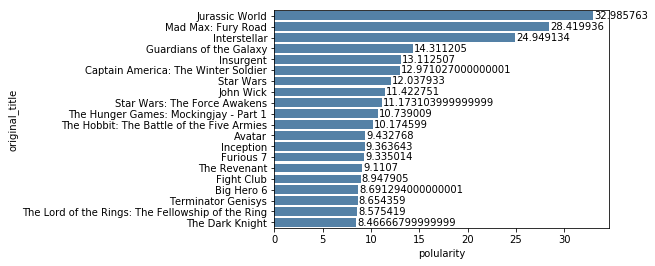

```python
top20 = clean_data.sort_values(by='popularity', ascending=False)[:20]

'''
plt.barh(top20['original_title'], top20['popularity'], align = 'center', color='steelblue', alpha = 1);
plt.xlabel('polularity')
for x,y in enumerate(top20['popularity']):
    plt.text(y+0.1,x,'%s' %y,va='center')
'''

sb.barplot(top20['popularity'], top20['original_title'], color='steelblue', orient='h');
plt.xlabel('polularity')
for x,y in enumerate(top20['popularity']):
    plt.text(y+0.1,x,'%s' %y,va='center')
```

**任务3.2：**分析电影净利润（票房-成本）随着年份变化的情况，并简单进行分析。

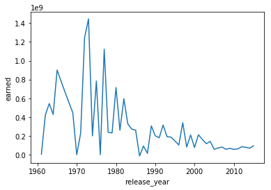

```python
earned = clean_data['revenue_adj'] - clean_data['budget_adj']
clean_data['earned'] = earned
earned_plt = pd.DataFrame(clean_data.groupby(['release_year'])['earned'].agg('mean'))
earned_plt = earned_plt.reset_index('release_year')
sb.lineplot(data = earned_plt, x='release_year', y='earned');
```

从上图可以看出，整个电影的净利润走向并不是一个比较平滑的折线。从最初到前期的起伏十分巨大，说明此时电影行业的利润情况是不稳定的。 在折线的最后我们可以发现，整个利润逐渐趋向于一个平稳的状态。说明电影行业发展到后面，利润情况已经难有巨大变化，预算和票房已经难有较大差值。

**[选做]任务3.3：**选择最多产的10位导演（电影数量最多的），绘制他们排行前3的三部电影的票房情况，并简要进行分析。

**[选做]任务3.4：**分析1968年~2015年六月电影的数量的变化。

**[选做]任务3.5：**分析1968年~2015年六月电影 `Comedy` 和 `Drama` 两类电影的数量的变化。

> 注意: 当你写完了所有的代码，并且回答了所有的问题。你就可以把你的 iPython Notebook 导出成 HTML 文件。你可以在菜单栏，这样导出**File -> Download as -> HTML (.html)、Python (.py)** 把导出的 HTML、python文件 和这个 iPython notebook 一起提交给审阅者。